# IBLM

Karol Gawlowski and Paul Beard

2025-11-17

## Installation

IBLM can be installed from CRAN or GitHub:

```r
# From CRAN
install.packages("IBLM")

# From GitHub
remotes::install_github("IFoA-ADSWP/IBLM")
```

## Introduction

IBLM stands for Interpretable Boosted Linear Models.

An IBLM is essentially a hybrid model consisting of two components:

1. Generalised Linear Model (GLM) - fitted to the training data
2. Booster Model[^1] - fitted to the residuals of the training data against GLM predictions in step 1.

The purpose of this Vignette is to show you how to use IBLM to train, explain and predict using functions from this package.

```r
library(IBLM)
library(dplyr)
```

## Process

The overall process for fitting and interpreting an IBLM is as follows:

**Step 1: Fit a GLM**

```
GLM prediction = β₀ + β₁x₁ + β₂x₂ + ... + βₐxₐ
```

Where β values are your standard regression coefficients.

**Step 2: Train a Booster on GLM’s Errors**

Train a booster model (i.e. XGBoost) on the residuals of the actual response values against the GLM predictions.

**Step 3: Use SHAP to Break Down the Booster**

SHAP decomposition allows the booster’s prediction to be apportioned into contributions from each feature:

```
Booster prediction = φ₀ + φ₁(x) + φ₂(x) + ... + φₐ(x)
```

Where φⱼ(x) is how much feature j contributed to this specific prediction.

**Step 4: Convert SHAP Values to Beta Coefficient Corrections**

Transform each SHAP contribution into beta corrections:

```
αⱼ(x) ≈ φⱼ(x) / xⱼ
```

For instances where xⱼ = 0 the αⱼ(x) is set to 0 and the value is instead added to an intercept correction, α0.

```
αⱼ(x) = 0 if xⱼ = 0
α0={j∣xj=0}∑ϕj(x)
```

**Step 5: Combine Them**

The final IBLM model can be interpreted as a collection of adjusted GLMs. Each row of the data will have its own GLM coefficients which are:

1. The GLM coefficients derived in step 1, which are the same for all rows
2. The beta corrections derived in step 4, which are unique to that predictor variable combination.

```
IBLM = (β₀ + φ₀ + α0) + (β₁ + α₁(x))x₁ + (β₂ + α₂(x))x₂ + ... + (βₐ + αₐ(x))xₐ
```

or

```
IBLM = β'₀ + β'₁x₁ + β'₂x₂ + ... + β'ₐxₐ
where β'ₐ = (βₐ + αₐ(x))
and β'₀ = β₀ + φ₀ + α0
```

This preserves the familiar GLM form while incorporating the booster’s superior predictive power.

## Train

To train an IBLM model we must get our data into an appropriate format. In this document our demonstrations will be completed using French motor claims dataset `freMTPL2freq`.

Data for training an IBLM model must be in the form of a list of 3 dataframes. These will be named “train”, “validate” and “test”. The function `split_into_train_validate_test()` can conveniently split a single dataframe into such a structure.

```r
df <- load_freMTPL2freq()

df <- df |> mutate(ClaimNb = round(ClaimNb))

df_list <- df |> split_into_train_validate_test(seed = 1)
```

There is currently only one function available to train an IBLM. This is `train_iblm_xgb()` which will use xgboost as the booster model. This performs steps 1 and 2 of the Process.

The output is of class “iblm”. Objects of this class contain two component models “glm_model” and “booster_model”. There are also other items containing information (see Value section of `train_iblm_xgb()` for more information)

```r
iblm_model <- train_iblm_xgb(
  df_list,
  response_var = "ClaimNb",
  family = "poisson"
)

class(iblm_model)
```

```
#> [1] "iblm"
```

## Explain

Code to explain and interpret an object of class “iblm” are conveniently wrapped in the `explain_iblm()` function. This performs steps 3, 4 and 5 of the Process. The values derived are all based on the `data` fed in, which would usually be the test portion of your dataset.

The following line is all that is required:

```r
ex <- explain_iblm(iblm_model, df_list$test)
```

The output object is a list containing the following items:

- **beta_corrected_scatter** Function to create scatter plots showing SHAP corrections vs variable values (see `beta_corrected_scatter()`)
- **beta_corrected_density** Function to create density plots of SHAP corrections for variables (see `beta_corrected_density()`)
- **bias_density** Function to create density plots of SHAP corrections migrated to bias (see `bias_density()`)
- **overall_correction** Function to show global correction distributions (see `overall_correction()`)
- **shap** Dataframe showing raw SHAP values of data records
- **beta_corrections** Dataframe showing beta corrections (in wide/one-hot format) of data records
- **data_beta_coeff** Dataframe showing beta coefficients of data records

Many of the items output are functions. The functions can then be called to observe the components of the “iblm” object in different ways.

### Corrected Betas Density

The corrected beta coefficients (β’ₐ) can be observed in a density plot.

This density plot will also show the standard error for the original beta coefficient fitted in the GLM model component. This can be useful to understanding the significance of the range in corrected beta coefficients.

```r
VehPower <- ex$beta_corrected_density(varname = "VehPower")

VehAge <- ex$beta_corrected_density(varname = "VehAge")

DrivAge <- ex$beta_corrected_density(varname = "DrivAge")

BonusMalus <- ex$beta_corrected_density(varname = "BonusMalus")
```

[output not shown]

When the argument varname is set to be a categorical predictor variable, a plot is produced for each separate level of that categorical variable.

This, however, does not include the reference level. As shown below - calling the function with “VehBrand”, which has 11 levels, produces 10 plots. Because “B1” was used as the reference level it does not have a beta coefficient within the GLM model component. Instead, those values are migrated to the bias (see below).

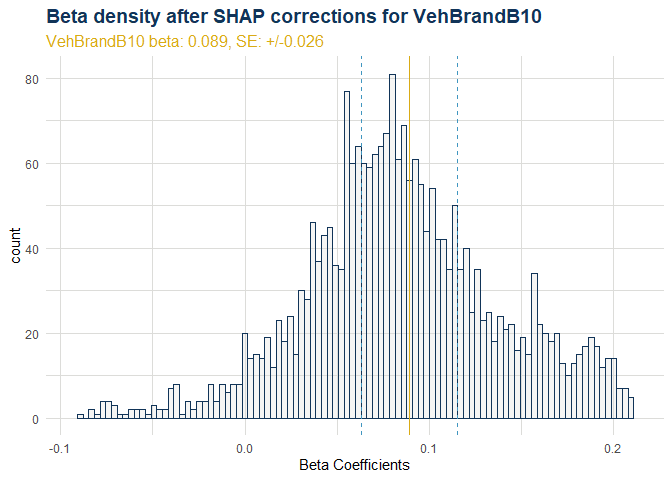

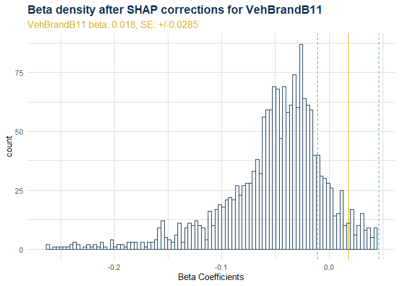

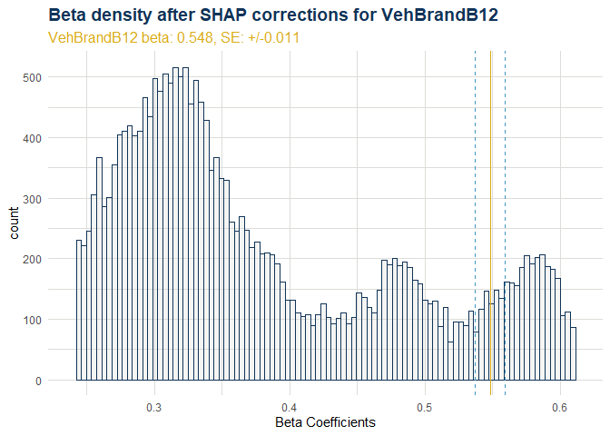

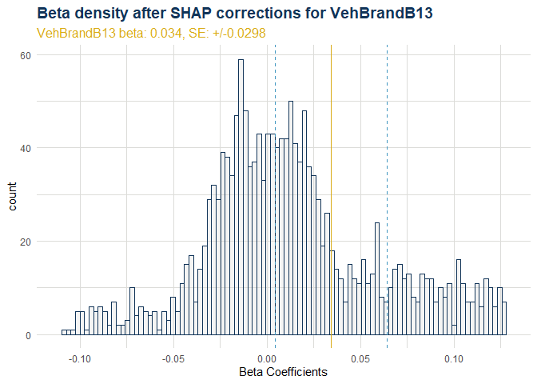

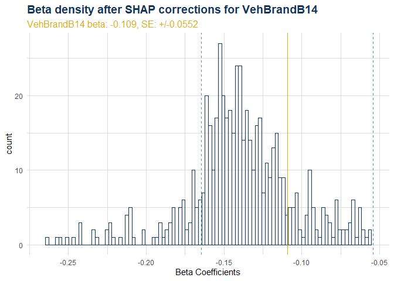

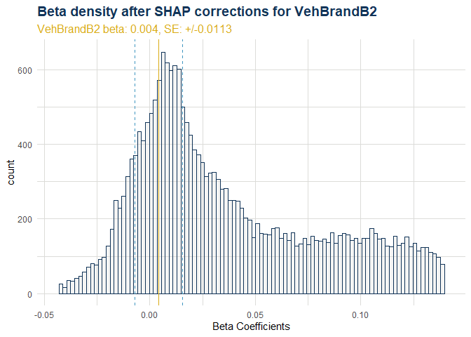

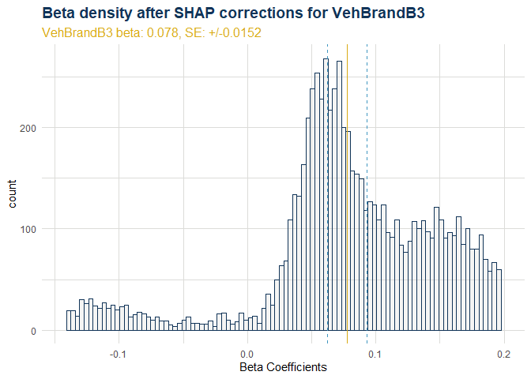

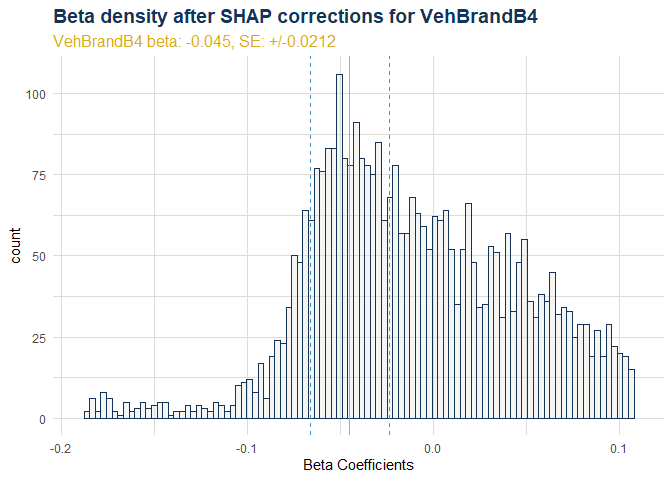

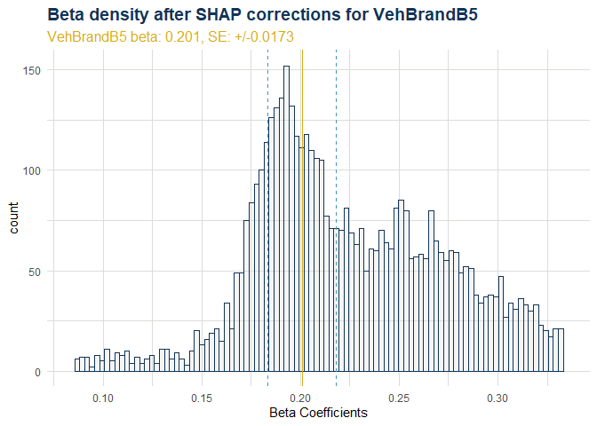

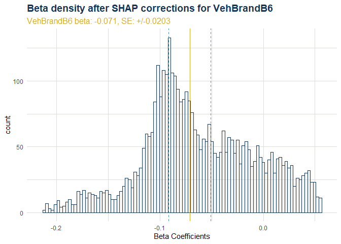

```r
VehBrand <- ex$beta_corrected_density(varname = "VehBrand", type = "hist")

VehBrand
```